```python
import pandas as pd
import numpy as np
import requests
import json
from IPython.display import display
from PIL import Image
```

```python
# let us load the twitter archive enhanced csv file
twitter_enhanced=pd.read_csv('twitter-archive-enhanced.csv')
twitter_enhanced.head(5)
```

|  | tweet_id | in_reply_to_status_id | in_reply_to_user_id | timestamp | source | text | retweeted_status_id | retweeted_status_user_id | retweeted_status_timestamp | expanded_urls | rating_numerator | rating_denominator | name | doggo | floofer | pupper | puppo |
| --- | --- | --- | --- | --- | --- | --- | --- | --- | --- | --- | --- | --- | --- | --- | --- | --- | --- |
| 0 | 892420643555336193 | NaN | NaN | 2017-08-01 16:23:56 +0000 | <a href="http://twitter.com/download/iphone" rel="nofollow">Twitter for iPhone</a> | This is Phineas. He's a mystical boy. Only ever appears in the hole of a donut. 13/10 https://t.co/MgUWQ76dJU | NaN | NaN | NaN | https://twitter.com/dog_rates/status/892420643555336193/photo/1 | 13 | 10 | Phineas | None | None | None | None |
| 1 | 892177421306343426 | NaN | NaN | 2017-08-01 00:17:27 +0000 | <a href="http://twitter.com/download/iphone" rel="nofollow">Twitter for iPhone</a> | This is Tilly. She's just checking pup on you. Hopes you're doing ok. If not, she's available for pats, snugs, boops, the whole bit. 13/10 https://t.co/0Xxu71qeIV | NaN | NaN | NaN | https://twitter.com/dog_rates/status/892177421306343426/photo/1 | 13 | 10 | Tilly | None | None | None | None |
| 2 | 891815181378084864 | NaN | NaN | 2017-07-31 00:18:03 +0000 | <a href="http://twitter.com/download/iphone" rel="nofollow">Twitter for iPhone</a> | This is Archie. He is a rare Norwegian Pouncing Corgo. Lives in the tall grass. You never know when one may strike. 12/10 https://t.co/wUnZnhtVJB | NaN | NaN | NaN | https://twitter.com/dog_rates/status/891815181378084864/photo/1 | 12 | 10 | Archie | None | None | None | None |
| 3 | 891689557279858688 | NaN | NaN | 2017-07-30 15:58:51 +0000 | <a href="http://twitter.com/download/iphone" rel="nofollow">Twitter for iPhone</a> | This is Darla. She commenced a snooze mid meal. 13/10 happens to the best of us https://t.co/tD36da7qLQ | NaN | NaN | NaN | https://twitter.com/dog_rates/status/891689557279858688/photo/1 | 13 | 10 | Darla | None | None | None | None |
| 4 | 891327558926688256 | NaN | NaN | 2017-07-29 16:00:24 +0000 | <a href="http://twitter.com/download/iphone" rel="nofollow">Twitter for iPhone</a> | This is Franklin. He would like you to stop calling him "cute." He is a very fierce shark and should be respected as such. 12/10 #BarkWeek https://t.co/AtUZn91f7f | NaN | NaN | NaN | https://twitter.com/dog_rates/status/891327558926688256/photo/1,https://twitter.com/dog_rates/status/891327558926688256/photo/1 | 12 | 10 | Franklin | None | None | None | None |

```python
twitter_enhanced.sample(5)
```

|  | tweet_id | in_reply_to_status_id | in_reply_to_user_id | timestamp | source | text | retweeted_status_id | retweeted_status_user_id | retweeted_status_timestamp | expanded_urls | rating_numerator | rating_denominator | name | doggo | floofer | pupper | puppo |
| --- | --- | --- | --- | --- | --- | --- | --- | --- | --- | --- | --- | --- | --- | --- | --- | --- | --- |
| 466 | 817171292965273600 | NaN | NaN | 2017-01-06 00:49:53 +0000 | <a href="http://twitter.com/download/iphone" rel="nofollow">Twitter for iPhone</a> | This is Tebow. He kindly requests that you put down the coffee and play with him. 13/10 such a good boy https://t.co/56uBP28eqw | NaN | NaN | NaN | https://twitter.com/dog_rates/status/817171292965273600/photo/1 | 13 | 10 | Tebow | None | None | None | None |
| 537 | 806629075125202948 | NaN | NaN | 2016-12-07 22:38:52 +0000 | <a href="http://twitter.com/download/iphone" rel="nofollow">Twitter for iPhone</a> | "Good afternoon class today we're going to learn what makes a good boy so good" 13/10 https://t.co/f1h2Fsalv9 | NaN | NaN | NaN | https://twitter.com/dog_rates/status/806629075125202948/photo/1,https://twitter.com/dog_rates/status/806629075125202948/photo/1 | 13 | 10 | None | None | None | None | None |
| 2125 | 670361874861563904 | NaN | NaN | 2015-11-27 22:01:40 +0000 | <a href="http://twitter.com/download/iphone" rel="nofollow">Twitter for iPhone</a> | This is a Rich Mahogany Seltzer named Cherokee. Just got destroyed by a snowball. Isn't very happy about it. 9/10 https://t.co/98ZBi6o4dj | NaN | NaN | NaN | https://twitter.com/dog_rates/status/670361874861563904/photo/1 | 9 | 10 | a | None | None | None | None |
| 1314 | 706901761596989440 | NaN | NaN | 2016-03-07 17:58:08 +0000 | <a href="http://twitter.com/download/iphone" rel="nofollow">Twitter for iPhone</a> | This is Elliot. He's blocking the roadway. Downright rude as hell. Doesn't care that you're already late. 3/10 https://t.co/FMUxir5pYu | NaN | NaN | NaN | https://twitter.com/dog_rates/status/706901761596989440/photo/1 | 3 | 10 | Elliot | None | None | None | None |
| 38 | 884925521741709313 | NaN | NaN | 2017-07-12 00:01:00 +0000 | <a href="http://twitter.com/download/iphone" rel="nofollow">Twitter for iPhone</a> | This is Earl. He found a hat. Nervous about what you think of it. 12/10 it's delightful, Earl https://t.co/MYJvdlNRVa | NaN | NaN | NaN | https://twitter.com/dog_rates/status/884925521741709313/photo/1 | 12 | 10 | Earl | None | None | None | None |

### Visual inspection :

#### There are some tidness issues

a) there are four columns for one variable which is dog breed

#### There are some quality issues

a) there are some Nans values  
b) there timestamp shall be of date type , we shall correct that for e.g by using parsetimes

```python
twitter_enhanced['text'][1635]
```

```
'Someone help the girl is being mugged. Several are distracting her while two steal her shoes. Clever puppers 121/110 https://t.co/1zfnTJLt55'
```

```python
twitter_enhanced['text'][2111]
```

```
"Meet Koda. He's large. Looks very soft. Great bangs. Powerful owner. 11/10 would pet the hell out of https://t.co/mzPoS9wCqp"
```

#### As it is shown above , the extracted dog name from the text source understands different paragraph beginning formats such as : Meet Koda or this is koda

#### But As all the texts don't have the same structure so there may be doubts that the extracted name column algorithm didn't cover all possible paragraph beginnings

#### To make sure of this let us take a sample for the dog name column that holds Nan Values

#### Let us mark this as the fourth quality issue.

```python
check_df1=twitter_enhanced[twitter_enhanced['name']=='None'] # sorting null values dogs names
```

```python
check_df1.text.head(15)[35] # I made alot of tries till I get this one , Here we notice that the dog name is howard , however as the format of the text doesn't match the 'name' column extraction algorithm . the name column is 'null'
```

```
'I have a new hero and his name is Howard. 14/10 https://t.co/gzLHboL7Sk'
```

```python
twitter_enhanced.name.value_counts()
```

```
None       745
a           55
Charlie     12
Lucy        11
Oliver      11
          ...
Strider      1
Blanket      1
Durg         1
Monty        1
Dot          1
Name: name, Length: 957, dtype: int64
```

#### the fifth quality issue is that some dogs names hold Nan Value while in the text there is a dog name .Also there are dog names with value : a.

```python
#Let us check if there are two breeds for the same dog
twitter_enhanced[(twitter_enhanced.pupper=='pupper') & (twitter_enhanced.floofer!='None')]
twitter_enhanced[(twitter_enhanced.doggo=='doggo') & (twitter_enhanced.floofer!='None')]
```

|  | tweet_id | in_reply_to_status_id | in_reply_to_user_id | timestamp | source | text | retweeted_status_id | retweeted_status_user_id | retweeted_status_timestamp | expanded_urls | rating_numerator | rating_denominator | name | doggo | floofer | pupper | puppo |
| --- | --- | --- | --- | --- | --- | --- | --- | --- | --- | --- | --- | --- | --- | --- | --- | --- | --- |
| 200 | 854010172552949760 | NaN | NaN | 2017-04-17 16:34:26 +0000 | <a href="http://twitter.com/download/iphone" rel="nofollow">Twitter for iPhone</a> | At first I thought this was a shy doggo, but it's actually a Rare Canadian Floofer Owl. Amateurs would confuse the two. 11/10 only send dogs https://t.co/TXdT3tmuYk | NaN | NaN | NaN | https://twitter.com/dog_rates/status/854010172552949760/photo/1,https://twitter.com/dog_rates/status/854010172552949760/photo/1 | 11 | 10 | None | doggo | floofer | None | None |

### we have caught the sixth quality issue , there is another quality issue : two dog stages are there for one dog

```python
pd.set_option('display.max_colwidth', None)
twitter_enhanced.iloc[[200]]
```

|  | tweet_id | in_reply_to_status_id | in_reply_to_user_id | timestamp | source | text | retweeted_status_id | retweeted_status_user_id | retweeted_status_timestamp | expanded_urls | rating_numerator | rating_denominator | name | doggo | floofer | pupper | puppo |
| --- | --- | --- | --- | --- | --- | --- | --- | --- | --- | --- | --- | --- | --- | --- | --- | --- | --- |
| 200 | 854010172552949760 | NaN | NaN | 2017-04-17 16:34:26 +0000 | <a href="http://twitter.com/download/iphone" rel="nofollow">Twitter for iPhone</a> | At first I thought this was a shy doggo, but it's actually a Rare Canadian Floofer Owl. Amateurs would confuse the two. 11/10 only send dogs https://t.co/TXdT3tmuYk | NaN | NaN | NaN | https://twitter.com/dog_rates/status/854010172552949760/photo/1,https://twitter.com/dog_rates/status/854010172552949760/photo/1 | 11 | 10 | None | doggo | floofer | None | None |

### It is clear that the problem there that the breed algorithm for example when filling the floofer column , it looks for the dogoo in the text and then fills it That is the problem when having four columns for one variable

### Let us check the another file which is the image prediction.tsv

```python
url = 'https://d17h27t6h515a5.cloudfront.net/topher/2017/August/599fd2ad_image-predictions/image-predictions.tsv'
r = requests.get(url, allow_redirects=True)
open('image-predictions.tsv', 'wb').write(r.content)
```

```
335079
```

```python
image_predictions_csv=pd.read_csv('image-predictions.tsv',sep="\t")
```

```python
image_predictions_csv.head(10)
```

|  | tweet_id | jpg_url | img_num | p1 | p1_conf | p1_dog | p2 | p2_conf | p2_dog | p3 | p3_conf | p3_dog |
| --- | --- | --- | --- | --- | --- | --- | --- | --- | --- | --- | --- | --- |
| 0 | 666020888022790149 | https://pbs.twimg.com/media/CT4udn0WwAA0aMy.jpg | 1 | Welsh_springer_spaniel | 0.465074 | True | collie | 0.156665 | True | Shetland_sheepdog | 0.061428 | True |
| 1 | 666029285002620928 | https://pbs.twimg.com/media/CT42GRgUYAA5iDo.jpg | 1 | redbone | 0.506826 | True | miniature_pinscher | 0.074192 | True | Rhodesian_ridgeback | 0.072010 | True |
| 2 | 666033412701032449 | https://pbs.twimg.com/media/CT4521TWwAEvMyu.jpg | 1 | German_shepherd | 0.596461 | True | malinois | 0.138584 | True | bloodhound | 0.116197 | True |
| 3 | 666044226329800704 | https://pbs.twimg.com/media/CT5Dr8HUEAA-lEu.jpg | 1 | Rhodesian_ridgeback | 0.408143 | True | redbone | 0.360687 | True | miniature_pinscher | 0.222752 | True |
| 4 | 666049248165822465 | https://pbs.twimg.com/media/CT5IQmsXIAAKY4A.jpg | 1 | miniature_pinscher | 0.560311 | True | Rottweiler | 0.243682 | True | Doberman | 0.154629 | True |
| 5 | 666050758794694657 | https://pbs.twimg.com/media/CT5Jof1WUAEuVxN.jpg | 1 | Bernese_mountain_dog | 0.651137 | True | English_springer | 0.263788 | True | Greater_Swiss_Mountain_dog | 0.016199 | True |
| 6 | 666051853826850816 | https://pbs.twimg.com/media/CT5KoJ1WoAAJash.jpg | 1 | box_turtle | 0.933012 | False | mud_turtle | 0.045885 | False | terrapin | 0.017885 | False |
| 7 | 666055525042405380 | https://pbs.twimg.com/media/CT5N9tpXIAAifs1.jpg | 1 | chow | 0.692517 | True | Tibetan_mastiff | 0.058279 | True | fur_coat | 0.054449 | False |
| 8 | 666057090499244032 | https://pbs.twimg.com/media/CT5PY90WoAAQGLo.jpg | 1 | shopping_cart | 0.962465 | False | shopping_basket | 0.014594 | False | golden_retriever | 0.007959 | True |
| 9 | 666058600524156928 | https://pbs.twimg.com/media/CT5Qw94XAAA_2dP.jpg | 1 | miniature_poodle | 0.201493 | True | komondor | 0.192305 | True | soft-coated_wheaten_terrier | 0.082086 | True |

```python
#it seems that some of the photos don't belong to a dog breed
#let us check if P1_dog is false
len(image_predictions_csv[image_predictions_csv['p1_dog']==False])
```

```
543
```

```python
#it seems above that there are 543 False predictions.it is either a problem in the predicting algorithm or the url directs to a false photo
#let us check for a sample
import urllib.request
```

```python
#It is clear that the higher confidence level which is P1 may not be correct however it was confident 0.9 ! as in that case P3 confidene level is the correct one.
# For better check let us create a dataframe with only false value in P1_dog &P2_dog & P3_dog
False_images=image_predictions_csv[(image_predictions_csv["p1_dog"]==False) & (image_predictions_csv["p2_dog"]==False) & ( image_predictions_csv["p3_dog"]==False)]
False_images.head()
False_images.info()
```

[output not shown]

```
<class 'pandas.core.frame.DataFrame'>
Int64Index: 324 entries, 6 to 2074
Data columns (total 12 columns):
 #   Column    Non-Null Count  Dtype
---  ------    --------------  -----
 0   tweet_id  324 non-null    int64
 1   jpg_url   324 non-null    object
 2   img_num   324 non-null    int64
 3   p1        324 non-null    object
 4   p1_conf   324 non-null    float64
 5   p1_dog    324 non-null    bool
 6   p2        324 non-null    object
 7   p2_conf   324 non-null    float64
 8   p2_dog    324 non-null    bool
 9   p3        324 non-null    object
 10  p3_conf   324 non-null    float64
 11  p3_dog    324 non-null    bool
dtypes: bool(3), float64(3), int64(2), object(4)
memory usage: 26.3+ KB
```

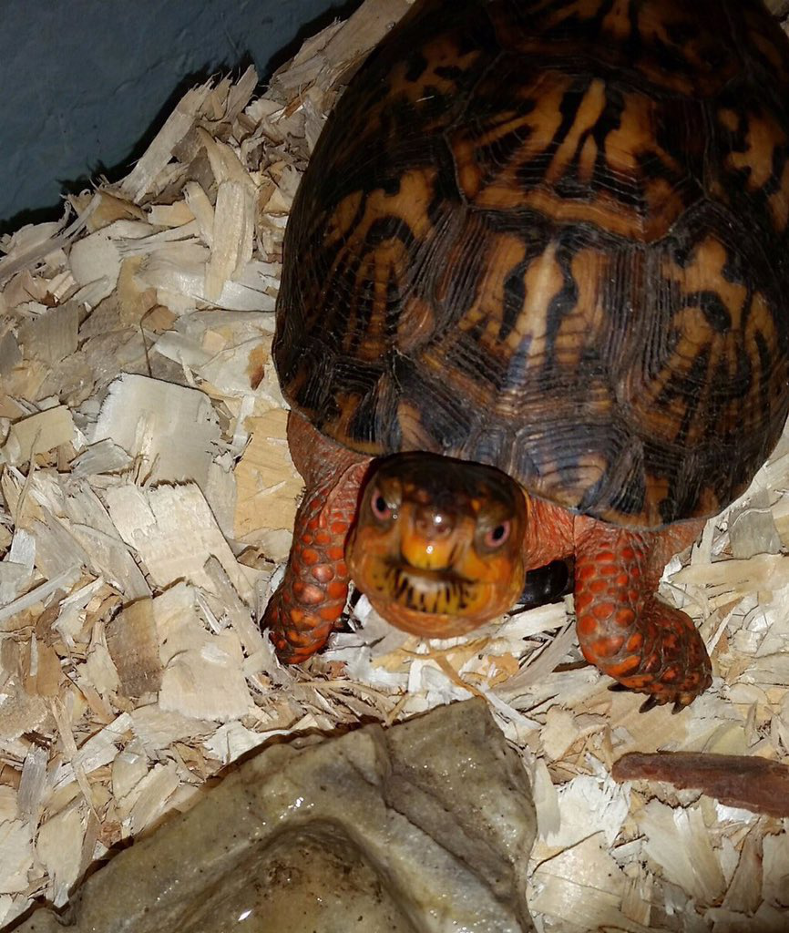

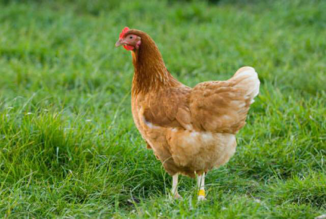

```python
#Let us check for this one , we may show the first two indices
url1=image_predictions_csv['jpg_url'][6]
url2=image_predictions_csv['jpg_url'][17]
urllib.request.urlretrieve(url1,"dog1.jpg")
display(Image.open("dog1.jpg"))
urllib.request.urlretrieve(url2,"dog2.jpg")
display(Image.open("dog2.jpg"))
```

#### this is the 7th Quality issue : there are 324 false dogs images.

```python
#lets get back to the twitter_enhanced.csv and check for the numerator/den. value counts
twitter_enhanced.rating_numerator.value_counts()
```

```
12      558
11      464
10      461
13      351
9       158
8       102
7        55
14       54
5        37
6        32
3        19
4        17
1         9
2         9
420       2
```

[output cut: 26 more lines]

### 8th quality issue > There are some outliers : I suggest remove those outliers as they are very extreme and will effect our plotting. .

```python
#There are some outliers like :960,1776,1,2,0 .. those outliers will effect our plotting.
#I suggest to remove those outliers in case of plotting.
# I will load the JSON File now and convert it to dataframe
df_Json_list = []
with open('tweet-json') as file:
    for line in file:
        tweet = json.loads(line)

        df_Json_list.append({
            'tweet_id': tweet['id'],
            'retweet_count': tweet['retweet_count'],
            'likes_count': tweet['favorite_count']
        })
df_Json = pd.DataFrame(df_Json_list, columns = ['tweet_id', 'retweet_count', 'likes_count'])

df_Json.head()
```

|  | tweet_id | retweet_count | likes_count |
| --- | --- | --- | --- |
| 0 | 892420643555336193 | 8853 | 39467 |
| 1 | 892177421306343426 | 6514 | 33819 |
| 2 | 891815181378084864 | 4328 | 25461 |
| 3 | 891689557279858688 | 8964 | 42908 |
| 4 | 891327558926688256 | 9774 | 41048 |

```python
df_Json.info()
```

```
<class 'pandas.core.frame.DataFrame'>
RangeIndex: 2354 entries, 0 to 2353
Data columns (total 3 columns):
 #   Column         Non-Null Count  Dtype
---  ------         --------------  -----
 0   tweet_id       2354 non-null   int64
 1   retweet_count  2354 non-null   int64
 2   likes_count    2354 non-null   int64
dtypes: int64(3)
memory usage: 55.3 KB
```

#### we shall remove the retweets.

```python
twitter_enhanced.info()
```

```
<class 'pandas.core.frame.DataFrame'>
RangeIndex: 2356 entries, 0 to 2355
Data columns (total 17 columns):
 #   Column                      Non-Null Count  Dtype
---  ------                      --------------  -----
 0   tweet_id                    2356 non-null   int64
 1   in_reply_to_status_id       78 non-null     float64
 2   in_reply_to_user_id         78 non-null     float64
 3   timestamp                   2356 non-null   object
 4   source                      2356 non-null   object
 5   text                        2356 non-null   object
 6   retweeted_status_id         181 non-null    float64
 7   retweeted_status_user_id    181 non-null    float64
 8   retweeted_status_timestamp  181 non-null    object
 9   expanded_urls               2297 non-null   object
 10  rating_numerator            2356 non-null   int64
 11  rating_denominator          2356 non-null   int64
 12  name                        2356 non-null   object
 13  doggo                       2356 non-null   object
 14  floofer                     2356 non-null   object
 15  pupper                      2356 non-null   object
 16  puppo                       2356 non-null   object
dtypes: float64(4), int64(3), object(10)
memory usage: 313.0+ KB
```

```python
# We would like to compare the tweet IDs in both files :
#A one simple way is to merge both DF by tweer id
combined_list = pd.merge(df_Json,twitter_enhanced,how='left',on='tweet_id')
```

```python
combined_list.info()
```

```
<class 'pandas.core.frame.DataFrame'>
Int64Index: 2354 entries, 0 to 2353
Data columns (total 19 columns):
 #   Column                      Non-Null Count  Dtype
---  ------                      --------------  -----
 0   tweet_id                    2354 non-null   int64
 1   retweet_count               2354 non-null   int64
 2   likes_count                 2354 non-null   int64
 3   in_reply_to_status_id       78 non-null     float64
 4   in_reply_to_user_id         78 non-null     float64
 5   timestamp                   2354 non-null   object
 6   source                      2354 non-null   object
 7   text                        2354 non-null   object
 8   retweeted_status_id         179 non-null    float64
 9   retweeted_status_user_id    179 non-null    float64
 10  retweeted_status_timestamp  179 non-null    object
 11  expanded_urls               2295 non-null   object
 12  rating_numerator            2354 non-null   int64
 13  rating_denominator          2354 non-null   int64
 14  name                        2354 non-null   object
 15  doggo                       2354 non-null   object
 16  floofer                     2354 non-null   object
 17  pupper                      2354 non-null   object
 18  puppo                       2354 non-null   object
dtypes: float64(4), int64(5), object(10)
memory usage: 367.8+ KB
```

```python
# As we see here ;there are 2354 tweet IDs in the combined list
# so there are two tweet ids ,most probable they are duplicated or retweets
# let us check
twitter_enhanced[twitter_enhanced['tweet_id'].duplicated()]#search for duplicated tags
```

|  | tweet_id | in_reply_to_status_id | in_reply_to_user_id | timestamp | source | text | retweeted_status_id | retweeted_status_user_id | retweeted_status_timestamp | expanded_urls | rating_numerator | rating_denominator | name | doggo | floofer | pupper | puppo |
| --- | --- | --- | --- | --- | --- | --- | --- | --- | --- | --- | --- | --- | --- | --- | --- | --- | --- |

#### let us search for the retweets

```python
twitter_enhanced[twitter_enhanced.text.str.match('^RT @')].info()
```

```
<class 'pandas.core.frame.DataFrame'>
Int64Index: 181 entries, 19 to 2260
Data columns (total 17 columns):
 #   Column                      Non-Null Count  Dtype
---  ------                      --------------  -----
 0   tweet_id                    181 non-null    int64
 1   in_reply_to_status_id       0 non-null      float64
 2   in_reply_to_user_id         0 non-null      float64
 3   timestamp                   181 non-null    object
 4   source                      181 non-null    object
 5   text                        181 non-null    object
 6   retweeted_status_id         181 non-null    float64
 7   retweeted_status_user_id    181 non-null    float64
 8   retweeted_status_timestamp  181 non-null    object
 9   expanded_urls               180 non-null    object
 10  rating_numerator            181 non-null    int64
 11  rating_denominator          181 non-null    int64
 12  name                        181 non-null    object
 13  doggo                       181 non-null    object
 14  floofer                     181 non-null    object
 15  pupper                      181 non-null    object
 16  puppo                       181 non-null    object
dtypes: float64(4), int64(3), object(10)
memory usage: 25.5+ KB
```

#### That is the ninth quality issue : some are retweets we shall drop them

# The Quality issues are :

## Twitter_enhanced_csv

1)the timestamp shall be of date type , we shall correct that for e.g by using parsetimes  
2)some dog names are : a  
3)some dog names hold Nan Values while the text included the dog names  
4) Two dog stages are there for one dog.  
5) outliers in dog rating numerators like 1776 , O ..etc.  
6) there are retweets . we shall drop them .

## Image_prediction

7) 324 false images that don't contain dog names  
8) Downsize P1,P2,P3 predictions

# The tidness issues are :

1)merge the three dataframes into one dataframe  
2)drop unneeded columns

# first we want to make a copy

```python
twitter_enhanced_clean=twitter_enhanced.copy()
image_predictions_csv_clean=image_predictions_csv.copy()
df_Json_clean=df_Json.copy()
```

# Twitter_enhanced :

## 1) merge dog stages in one column

## 2) drop unwanted columns

```python
# 1) let us combine the dog breeds in one column
twitter_enhanced_clean['dog_stage']='None'
for row in range(len(twitter_enhanced_clean.index)):
    dog_stage=[]
    if(twitter_enhanced_clean.doggo.loc[row]=='doggo'):
        dog_stage.append('doggo')
    if(twitter_enhanced_clean.floofer.loc[row]=='floofer'):
        dog_stage.append('floofer')
    if(twitter_enhanced_clean.puppo.loc[row]=='puppo'):
        dog_stage.append('puppo')
    if(twitter_enhanced_clean.pupper.loc[row]=='pupper'):
        dog_stage.append('pupper')
    if(dog_stage!=[]):
        twitter_enhanced_clean.dog_stage.loc[row]=','.join(dog_stage)
    elif(dog_stage==[]):
        twitter_enhanced_clean.dog_stage.loc[row]='None'

twitter_enhanced_clean=twitter_enhanced_clean.drop(['floofer','pupper','puppo','doggo','retweeted_status_id','retweeted_status_user_id','retweeted_status_timestamp'],axis=1)
```

[output not shown]

```python
twitter_enhanced_clean.info() #test
```

```
<class 'pandas.core.frame.DataFrame'>
RangeIndex: 2356 entries, 0 to 2355
Data columns (total 11 columns):
 #   Column                 Non-Null Count  Dtype
---  ------                 --------------  -----
 0   tweet_id               2356 non-null   int64
 1   in_reply_to_status_id  78 non-null     float64
 2   in_reply_to_user_id    78 non-null     float64
 3   timestamp              2356 non-null   object
 4   source                 2356 non-null   object
 5   text                   2356 non-null   object
 6   expanded_urls          2297 non-null   object
 7   rating_numerator       2356 non-null   int64
 8   rating_denominator     2356 non-null   int64
 9   name                   2356 non-null   object
 10  dog_stage              2356 non-null   object
dtypes: float64(2), int64(3), object(6)
memory usage: 202.6+ KB
```

```python
twitter_enhanced_clean.dog_stage.value_counts() #test
```

```
None             1976
pupper            245
doggo              83
puppo              29
doggo,pupper       12
floofer             9
doggo,floofer       1
doggo,puppo         1
Name: dog_stage, dtype: int64
```

# twitter_enhanced

## 3) Name is sometimes : a

```python
# let us see filter by name = 'a'
twitter_enhanced_clean[twitter_enhanced_clean.name=='a']
```

|  | tweet_id | in_reply_to_status_id | in_reply_to_user_id | timestamp | source | text | expanded_urls | rating_numerator | rating_denominator | name | dog_stage |
| --- | --- | --- | --- | --- | --- | --- | --- | --- | --- | --- | --- |
| 56 | 881536004380872706 | NaN | NaN | 2017-07-02 15:32:16 +0000 | <a href="http://twitter.com/download/iphone" rel="nofollow">Twitter for iPhone</a> | Here is a pupper approaching maximum borkdrive. Zooming at never before seen speeds. 14/10 paw-inspiring af \n(IG: puffie_the_chow) https://t.co/ghXBIIeQZF | https://twitter.com/dog_rates/status/881536004380872706/video/1 | 14 | 10 | a | pupper |
| 649 | 792913359805018113 | NaN | NaN | 2016-10-31 02:17:31 +0000 | <a href="http://twitter.com/download/iphone" rel="nofollow">Twitter for iPhone</a> | Here is a perfect example of someone who has their priorities in order. 13/10 for both owner and Forrest https://t.co/LRyMrU7Wfq | https://twitter.com/dog_rates/status/792913359805018113/photo/1,https://twitter.com/dog_rates/status/792913359805018113/photo/1,https://twitter.com/dog_rates/status/792913359805018113/photo/1,https://… | 13 | 10 | a | None |
| 801 | 772581559778025472 | NaN | NaN | 2016-09-04 23:46:12 +0000 | <a href="http://twitter.com/download/iphone" rel="nofollow">Twitter for iPhone</a> | Guys this is getting so out of hand. We only rate dogs. This is a Galapagos Speed Panda. Pls only send dogs... 10/10 https://t.co/8lpAGaZRFn | https://twitter.com/dog_rates/status/772581559778025472/photo/1,https://twitter.com/dog_rates/status/772581559778025472/photo/1,https://twitter.com/dog_rates/status/772581559778025472/photo/1 | 10 | 10 | a | None |
| 1002 | 747885874273214464 | NaN | NaN | 2016-06-28 20:14:22 +0000 | <a href="http://twitter.com/download/iphone" rel="nofollow">Twitter for iPhone</a> | This is a mighty rare blue-tailed hammer sherk. Human almost lost a limb trying to take these. Be careful guys. 8/10 https://t.co/TGenMeXreW | https://twitter.com/dog_rates/status/747885874273214464/photo/1,https://twitter.com/dog_rates/status/747885874273214464/photo/1 | 8 | 10 | a | None |
| 1004 | 747816857231626240 | NaN | NaN | 2016-06-28 15:40:07 +0000 | <a href="http://twitter.com/download/iphone" rel="nofollow">Twitter for iPhone</a> | Viewer discretion is advised. This is a terrible attack in progress. Not even in water (tragic af). 4/10 bad sherk https://t.co/L3U0j14N5R | https://twitter.com/dog_rates/status/747816857231626240/photo/1 | 4 | 10 | a | None |
| 1017 | 746872823977771008 | NaN | NaN | 2016-06-26 01:08:52 +0000 | <a href="http://twitter.com/download/iphone" rel="nofollow">Twitter for iPhone</a> | This is a carrot. We only rate dogs. Please only send in dogs. You all really should know this by now ...11/10 https://t.co/9e48aPrBm2 | https://twitter.com/dog_rates/status/746872823977771008/photo/1,https://twitter.com/dog_rates/status/746872823977771008/photo/1 | 11 | 10 | a | None |
| 1049 | 743222593470234624 | NaN | NaN | 2016-06-15 23:24:09 +0000 | <a href="http://twitter.com/download/iphone" rel="nofollow">Twitter for iPhone</a> | This is a very rare Great Alaskan Bush Pupper. Hard to stumble upon without spooking. 12/10 would pet passionately https://t.co/xOBKCdpzaa | https://twitter.com/dog_rates/status/743222593470234624/photo/1 | 12 | 10 | a | pupper |
| 1193 | 717537687239008257 | NaN | NaN | 2016-04-06 02:21:30 +0000 | <a href="http://twitter.com/download/iphone" rel="nofollow">Twitter for iPhone</a> | People please. This is a Deadly Mediterranean Plop T-Rex. We only rate dogs. Only send in dogs. Thanks you... 11/10 https://t.co/2ATDsgHD4n | https://twitter.com/dog_rates/status/717537687239008257/photo/1 | 11 | 10 | a | None |
| 1207 | 715733265223708672 | NaN | NaN | 2016-04-01 02:51:22 +0000 | <a href="http://twitter.com/download/iphone" rel="nofollow">Twitter for iPhone</a> | This is a taco. We only rate dogs. Please only send in dogs. Dogs are what we rate. Not tacos. Thank you... 10/10 https://t.co/cxl6xGY8B9 | https://twitter.com/dog_rates/status/715733265223708672/photo/1 | 10 | 10 | a | None |
| 1340 | 704859558691414016 | NaN | NaN | 2016-03-02 02:43:09 +0000 | <a href="http://twitter.com/download/iphone" rel="nofollow">Twitter for iPhone</a> | Here is a heartbreaking scene of an incredible pupper being laid to rest. 10/10 RIP pupper https://t.co/81mvJ0rGRu | https://twitter.com/dog_rates/status/704859558691414016/photo/1 | 10 | 10 | a | pupper |
| 1351 | 704054845121142784 | NaN | NaN | 2016-02-28 21:25:30 +0000 | <a href="http://twitter.com/download/iphone" rel="nofollow">Twitter for iPhone</a> | Here is a whole flock of puppers. 60/50 I'll take the lot https://t.co/9dpcw6MdWa | https://twitter.com/dog_rates/status/704054845121142784/photo/1 | 60 | 50 | a | None |
| 1361 | 703079050210877440 | NaN | NaN | 2016-02-26 04:48:02 +0000 | <a href="http://twitter.com/download/iphone" rel="nofollow">Twitter for iPhone</a> | This is a Butternut Cumberfloof. It's not windy they just look like that. 11/10 back at it again with the red socks https://t.co/hMjzhdUHaW | https://twitter.com/dog_rates/status/703079050210877440/photo/1,https://twitter.com/dog_rates/status/703079050210877440/photo/1 | 11 | 10 | a | None |
| 1368 | 702539513671897089 | NaN | NaN | 2016-02-24 17:04:07 +0000 | <a href="http://twitter.com/download/iphone" rel="nofollow">Twitter for iPhone</a> | This is a Wild Tuscan Poofwiggle. Careful not to startle. Rare tongue slip. One eye magical. 12/10 would def pet https://t.co/4EnShAQjv6 | https://twitter.com/dog_rates/status/702539513671897089/photo/1,https://twitter.com/dog_rates/status/702539513671897089/photo/1,https://twitter.com/dog_rates/status/702539513671897089/photo/1 | 12 | 10 | a | None |
| 1382 | 700864154249383937 | NaN | NaN | 2016-02-20 02:06:50 +0000 | <a href="http://twitter.com/download/iphone" rel="nofollow">Twitter for iPhone</a> | "Pupper is a present to world. Here is a bow for pupper." 12/10 precious as hell https://t.co/ItSsE92gCW | https://twitter.com/dog_rates/status/700864154249383937/photo/1 | 12 | 10 | a | pupper |
| 1499 | 692187005137076224 | NaN | NaN | 2016-01-27 03:26:56 +0000 | <a href="http://twitter.com/download/iphone" rel="nofollow">Twitter for iPhone</a> | This is a rare Arctic Wubberfloof. Unamused by the happenings. No longer has the appetites. 12/10 would totally hug https://t.co/krvbacIX0N | https://twitter.com/dog_rates/status/692187005137076224/photo/1,https://twitter.com/dog_rates/status/692187005137076224/photo/1,https://twitter.com/dog_rates/status/692187005137076224/photo/1 | 12 | 10 | a | None |
| 1737 | 679530280114372609 | NaN | NaN | 2015-12-23 05:13:38 +0000 | <a href="http://twitter.com/download/iphone" rel="nofollow">Twitter for iPhone</a> | Guys this really needs to stop. We've been over this way too many times. This is a giraffe. We only rate dogs.. 7/10 https://t.co/yavgkHYPOC | https://twitter.com/dog_rates/status/679530280114372609/photo/1 | 7 | 10 | a | None |
| 1785 | 677644091929329666 | NaN | NaN | 2015-12-18 00:18:36 +0000 | <a href="http://twitter.com/download/iphone" rel="nofollow">Twitter for iPhone</a> | This is a dog swinging. I really enjoyed it so I hope you all do as well. 11/10 https://t.co/Ozo9KHTRND | https://twitter.com/dog_rates/status/677644091929329666/video/1 | 11 | 10 | a | None |
| 1853 | 675706639471788032 | NaN | NaN | 2015-12-12 15:59:51 +0000 | <a href="http://twitter.com/download/iphone" rel="nofollow">Twitter for iPhone</a> | This is a Sizzlin Menorah spaniel from Brooklyn named Wylie. Lovable eyes. Chiller as hell. 10/10 and I'm out.. poof https://t.co/7E0AiJXPmI | https://twitter.com/dog_rates/status/675706639471788032/photo/1 | 10 | 10 | a | None |
| 1854 | 675534494439489536 | NaN | NaN | 2015-12-12 04:35:48 +0000 | <a href="http://twitter.com/download/iphone" rel="nofollow">Twitter for iPhone</a> | Seriously guys?! Only send in dogs. I only rate dogs. This is a baby black bear... 11/10 https://t.co/H7kpabTfLj | https://twitter.com/dog_rates/status/675534494439489536/photo/1 | 11 | 10 | a | None |
| 1877 | 675109292475830276 | NaN | NaN | 2015-12-11 00:26:12 +0000 | <a href="http://twitter.com/download/iphone" rel="nofollow">Twitter for iPhone</a> | C'mon guys. We've been over this. We only rate dogs. This is a cow. Please only submit dogs. Thank you...... 9/10 https://t.co/WjcELNEqN2 | https://twitter.com/dog_rates/status/675109292475830276/photo/1 | 9 | 10 | a | None |
| 1878 | 675047298674663426 | NaN | NaN | 2015-12-10 20:19:52 +0000 | <a href="http://twitter.com/download/iphone" rel="nofollow">Twitter for iPhone</a> | This is a fluffy albino Bacardi Columbia mix. Excellent at the tweets. 11/10 would hug gently https://t.co/diboDRUuEI | https://twitter.com/dog_rates/status/675047298674663426/photo/1 | 11 | 10 | a | None |
| 1923 | 674082852460433408 | NaN | NaN | 2015-12-08 04:27:30 +0000 | <a href="http://twitter.com/download/iphone" rel="nofollow">Twitter for iPhone</a> | This is a Sagitariot Baklava mix. Loves her new hat. 11/10 radiant pup https://t.co/Bko5kFJYUU | https://twitter.com/dog_rates/status/674082852460433408/photo/1 | 11 | 10 | a | None |
| 1941 | 673715861853720576 | NaN | NaN | 2015-12-07 04:09:13 +0000 | <a href="http://twitter.com/download/iphone" rel="nofollow">Twitter for iPhone</a> | This is a heavily opinionated dog. Loves walls. Nobody knows how the hair works. Always ready for a kiss. 4/10 https://t.co/dFiaKZ9cDl | https://twitter.com/dog_rates/status/673715861853720576/photo/1 | 4 | 10 | a | None |
| 1955 | 673636718965334016 | NaN | NaN | 2015-12-06 22:54:44 +0000 | <a href="http://twitter.com/download/iphone" rel="nofollow">Twitter for iPhone</a> | This is a Lofted Aphrodisiac Terrier named Kip. Big fan of bed n breakfasts. Fits perfectly. 10/10 would pet firmly https://t.co/gKlLpNzIl3 | https://twitter.com/dog_rates/status/673636718965334016/photo/1 | 10 | 10 | a | None |
| 1994 | 672604026190569472 | NaN | NaN | 2015-12-04 02:31:10 +0000 | <a href="http://twitter.com/download/iphone" rel="nofollow">Twitter for iPhone</a> | This is a baby Rand Paul. Curls for days. 11/10 would cuddle the hell out of https://t.co/xHXNaPAYRe | https://twitter.com/dog_rates/status/672604026190569472/photo/1 | 11 | 10 | a | None |
| 2034 | 671743150407421952 | NaN | NaN | 2015-12-01 17:30:22 +0000 | <a href="http://twitter.com/download/iphone" rel="nofollow">Twitter for iPhone</a> | This is a Tuscaloosa Alcatraz named Jacob (Yacōb). Loves to sit in swing. Stellar tongue. 11/10 look at his feet https://t.co/2IslQ8ZSc7 | https://twitter.com/dog_rates/status/671743150407421952/photo/1 | 11 | 10 | a | None |
| 2066 | 671147085991960577 | NaN | NaN | 2015-11-30 02:01:49 +0000 | <a href="http://twitter.com/download/iphone" rel="nofollow">Twitter for iPhone</a> | This is a Helvetica Listerine named Rufus. This time Rufus will be ready for the UPS guy. He'll never expect it 9/10 https://t.co/34OhVhMkVr | https://twitter.com/dog_rates/status/671147085991960577/photo/1 | 9 | 10 | a | None |
| 2116 | 670427002554466305 | NaN | NaN | 2015-11-28 02:20:27 +0000 | <a href="http://twitter.com/download/iphone" rel="nofollow">Twitter for iPhone</a> | This is a Deciduous Trimester mix named Spork. Only 1 ear works. No seat belt. Incredibly reckless. 9/10 still cute https://t.co/CtuJoLHiDo | https://twitter.com/dog_rates/status/670427002554466305/photo/1 | 9 | 10 | a | None |
| 2125 | 670361874861563904 | NaN | NaN | 2015-11-27 22:01:40 +0000 | <a href="http://twitter.com/download/iphone" rel="nofollow">Twitter for iPhone</a> | This is a Rich Mahogany Seltzer named Cherokee. Just got destroyed by a snowball. Isn't very happy about it. 9/10 https://t.co/98ZBi6o4dj | https://twitter.com/dog_rates/status/670361874861563904/photo/1 | 9 | 10 | a | None |
| 2128 | 670303360680108032 | NaN | NaN | 2015-11-27 18:09:09 +0000 | <a href="http://twitter.com/download/iphone" rel="nofollow">Twitter for iPhone</a> | This is a Speckled Cauliflower Yosemite named Hemry. He's terrified of intruder dog. Not one bit comfortable. 9/10 https://t.co/yV3Qgjh8iN | https://twitter.com/dog_rates/status/670303360680108032/photo/1 | 9 | 10 | a | None |
| 2146 | 669923323644657664 | NaN | NaN | 2015-11-26 16:59:01 +0000 | <a href="http://twitter.com/download/iphone" rel="nofollow">Twitter for iPhone</a> | This is a spotted Lipitor Rumpelstiltskin named Alphred. He can't wait for the Turkey. 10/10 would pet really well https://t.co/6GUGO7azNX | https://twitter.com/dog_rates/status/669923323644657664/photo/1 | 10 | 10 | a | None |
| 2153 | 669661792646373376 | NaN | NaN | 2015-11-25 23:39:47 +0000 | <a href="http://twitter.com/download/iphone" rel="nofollow">Twitter for iPhone</a> | This is a brave dog. Excellent free climber. Trying to get closer to God. Not very loyal though. Doesn't bark. 5/10 https://t.co/ODnILTr4QM | https://twitter.com/dog_rates/status/669661792646373376/photo/1 | 5 | 10 | a | None |
| 2161 | 669564461267722241 | NaN | NaN | 2015-11-25 17:13:02 +0000 | <a href="http://twitter.com/download/iphone" rel="nofollow">Twitter for iPhone</a> | This is a Coriander Baton Rouge named Alfredo. Loves to cuddle with smaller well-dressed dog. 10/10 would hug lots https://t.co/eCRdwouKCl | https://twitter.com/dog_rates/status/669564461267722241/photo/1 | 10 | 10 | a | None |
| 2191 | 668955713004314625 | NaN | NaN | 2015-11-24 00:54:05 +0000 | <a href="http://twitter.com/download/iphone" rel="nofollow">Twitter for iPhone</a> | This is a Slovakian Helter Skelter Feta named Leroi. Likes to skip on roofs. Good traction. Much balance. 10/10 wow! https://t.co/Dmy2mY2Qj5 | https://twitter.com/dog_rates/status/668955713004314625/photo/1 | 10 | 10 | a | None |
| 2198 | 668815180734689280 | NaN | NaN | 2015-11-23 15:35:39 +0000 | <a href="http://twitter.com/download/iphone" rel="nofollow">Twitter for iPhone</a> | This is a wild Toblerone from Papua New Guinea. Mouth always open. Addicted to hay. Acts blind. 7/10 handsome dog https://t.co/IGmVbz07tZ | https://twitter.com/dog_rates/status/668815180734689280/photo/1 | 7 | 10 | a | None |
| 2211 | 668614819948453888 | NaN | NaN | 2015-11-23 02:19:29 +0000 | <a href="http://twitter.com/download/iphone" rel="nofollow">Twitter for iPhone</a> | Here is a horned dog. Much grace. Can jump over moons (dam!). Paws not soft. Bad at barking. 7/10 can still pet tho https://t.co/2Su7gmsnZm | https://twitter.com/dog_rates/status/668614819948453888/photo/1 | 7 | 10 | a | None |
| 2218 | 668507509523615744 | NaN | NaN | 2015-11-22 19:13:05 +0000 | <a href="http://twitter.com/download/iphone" rel="nofollow">Twitter for iPhone</a> | This is a Birmingham Quagmire named Chuk. Loves to relax and watch the game while sippin on that iced mocha. 10/10 https://t.co/HvNg9JWxFt | https://twitter.com/dog_rates/status/668507509523615744/photo/1 | 10 | 10 | a | None |
| 2222 | 668466899341221888 | NaN | NaN | 2015-11-22 16:31:42 +0000 | <a href="http://twitter.com/download/iphone" rel="nofollow">Twitter for iPhone</a> | Here is a mother dog caring for her pups. Snazzy red mohawk. Doesn't wag tail. Pups look confused. Overall 4/10 https://t.co/YOHe6lf09m | https://twitter.com/dog_rates/status/668466899341221888/photo/1 | 4 | 10 | a | None |
| 2235 | 668171859951755264 | NaN | NaN | 2015-11-21 20:59:20 +0000 | <a href="http://twitter.com/download/iphone" rel="nofollow">Twitter for iPhone</a> | This is a Trans Siberian Kellogg named Alfonso. Huge ass eyeballs. Actually Dobby from Harry Potter. 7/10 https://t.co/XpseHBlAAb | https://twitter.com/dog_rates/status/668171859951755264/photo/1 | 7 | 10 | a | None |
| 2249 | 667861340749471744 | NaN | NaN | 2015-11-21 00:25:26 +0000 | <a href="http://twitter.com/download/iphone" rel="nofollow">Twitter for iPhone</a> | This is a Shotokon Macadamia mix named Cheryl. Sophisticated af. Looks like a disappointed librarian. Shh (lol) 9/10 https://t.co/J4GnJ5Swba | https://twitter.com/dog_rates/status/667861340749471744/photo/1 | 9 | 10 | a | None |
| 2255 | 667773195014021121 | NaN | NaN | 2015-11-20 18:35:10 +0000 | <a href="http://twitter.com" rel="nofollow">Twitter Web Client</a> | This is a rare Hungarian Pinot named Jessiga. She is either mid-stroke or got stuck in the washing machine. 8/10 https://t.co/ZU0i0KJyqD | https://twitter.com/dog_rates/status/667773195014021121/photo/1 | 8 | 10 | a | None |
| 2264 | 667538891197542400 | NaN | NaN | 2015-11-20 03:04:08 +0000 | <a href="http://twitter.com" rel="nofollow">Twitter Web Client</a> | This is a southwest Coriander named Klint. Hat looks expensive. Still on house arrest :(\n9/10 https://t.co/IQTOMqDUIe | https://twitter.com/dog_rates/status/667538891197542400/photo/1 | 9 | 10 | a | None |
| 2273 | 667470559035432960 | NaN | NaN | 2015-11-19 22:32:36 +0000 | <a href="http://twitter.com" rel="nofollow">Twitter Web Client</a> | This is a northern Wahoo named Kohl. He runs this town. Chases tumbleweeds. Draws gun wicked fast. 11/10 legendary https://t.co/J4vn2rOYFk | https://twitter.com/dog_rates/status/667470559035432960/photo/1 | 11 | 10 | a | None |
| 2287 | 667177989038297088 | NaN | NaN | 2015-11-19 03:10:02 +0000 | <a href="http://twitter.com/download/iphone" rel="nofollow">Twitter for iPhone</a> | This is a Dasani Kingfisher from Maine. His name is Daryl. Daryl doesn't like being swallowed by a panda. 8/10 https://t.co/jpaeu6LNmW | https://twitter.com/dog_rates/status/667177989038297088/photo/1 | 8 | 10 | a | None |
| 2304 | 666983947667116034 | NaN | NaN | 2015-11-18 14:18:59 +0000 | <a href="http://twitter.com/download/iphone" rel="nofollow">Twitter for iPhone</a> | This is a curly Ticonderoga named Pepe. No feet. Loves to jet ski. 11/10 would hug until forever https://t.co/cyDfaK8NBc | https://twitter.com/dog_rates/status/666983947667116034/photo/1 | 11 | 10 | a | None |
| 2311 | 666781792255496192 | NaN | NaN | 2015-11-18 00:55:42 +0000 | <a href="http://twitter.com/download/iphone" rel="nofollow">Twitter for iPhone</a> | This is a purebred Bacardi named Octaviath. Can shoot spaghetti out of mouth. 10/10 https://t.co/uEvsGLOFHa | https://twitter.com/dog_rates/status/666781792255496192/photo/1 | 10 | 10 | a | None |
| 2314 | 666701168228331520 | NaN | NaN | 2015-11-17 19:35:19 +0000 | <a href="http://twitter.com/download/iphone" rel="nofollow">Twitter for iPhone</a> | This is a golden Buckminsterfullerene named Johm. Drives trucks. Lumberjack (?). Enjoys wall. 8/10 would hug softly https://t.co/uQbZJM2DQB | https://twitter.com/dog_rates/status/666701168228331520/photo/1 | 8 | 10 | a | None |
| 2327 | 666407126856765440 | NaN | NaN | 2015-11-17 00:06:54 +0000 | <a href="http://twitter.com/download/iphone" rel="nofollow">Twitter for iPhone</a> | This is a southern Vesuvius bumblegruff. Can drive a truck (wow). Made friends with 5 other nifty dogs (neat). 7/10 https://t.co/LopTBkKa8h | https://twitter.com/dog_rates/status/666407126856765440/photo/1 | 7 | 10 | a | None |
| 2334 | 666293911632134144 | NaN | NaN | 2015-11-16 16:37:02 +0000 | <a href="http://twitter.com/download/iphone" rel="nofollow">Twitter for iPhone</a> | This is a funny dog. Weird toes. Won't come down. Loves branch. Refuses to eat his food. Hard to cuddle with. 3/10 https://t.co/IIXis0zta0 | https://twitter.com/dog_rates/status/666293911632134144/photo/1 | 3 | 10 | a | None |
| 2347 | 666057090499244032 | NaN | NaN | 2015-11-16 00:55:59 +0000 | <a href="http://twitter.com/download/iphone" rel="nofollow">Twitter for iPhone</a> | My oh my. This is a rare blond Canadian terrier on wheels. Only $8.98. Rather docile. 9/10 very rare https://t.co/yWBqbrzy8O | https://twitter.com/dog_rates/status/666057090499244032/photo/1 | 9 | 10 | a | None |
| 2348 | 666055525042405380 | NaN | NaN | 2015-11-16 00:49:46 +0000 | <a href="http://twitter.com/download/iphone" rel="nofollow">Twitter for iPhone</a> | Here is a Siberian heavily armored polar bear mix. Strong owner. 10/10 I would do unspeakable things to pet this dog https://t.co/rdivxLiqEt | https://twitter.com/dog_rates/status/666055525042405380/photo/1 | 10 | 10 | a | None |
| 2350 | 666050758794694657 | NaN | NaN | 2015-11-16 00:30:50 +0000 | <a href="http://twitter.com/download/iphone" rel="nofollow">Twitter for iPhone</a> | This is a truly beautiful English Wilson Staff retriever. Has a nice phone. Privileged. 10/10 would trade lives with https://t.co/fvIbQfHjIe | https://twitter.com/dog_rates/status/666050758794694657/photo/1 | 10 | 10 | a | None |
| 2352 | 666044226329800704 | NaN | NaN | 2015-11-16 00:04:52 +0000 | <a href="http://twitter.com/download/iphone" rel="nofollow">Twitter for iPhone</a> | This is a purebred Piers Morgan. Loves to Netflix and chill. Always looks like he forgot to unplug the iron. 6/10 https://t.co/DWnyCjf2mx | https://twitter.com/dog_rates/status/666044226329800704/photo/1 | 6 | 10 | a | None |
| 2353 | 666033412701032449 | NaN | NaN | 2015-11-15 23:21:54 +0000 | <a href="http://twitter.com/download/iphone" rel="nofollow">Twitter for iPhone</a> | Here is a very happy pup. Big fan of well-maintained decks. Just look at that tongue. 9/10 would cuddle af https://t.co/y671yMhoiR | https://twitter.com/dog_rates/status/666033412701032449/photo/1 | 9 | 10 | a | None |
| 2354 | 666029285002620928 | NaN | NaN | 2015-11-15 23:05:30 +0000 | <a href="http://twitter.com/download/iphone" rel="nofollow">Twitter for iPhone</a> | This is a western brown Mitsubishi terrier. Upset about leaf. Actually 2 dogs here. 7/10 would walk the shit out of https://t.co/r7mOb2m0UI | https://twitter.com/dog_rates/status/666029285002620928/photo/1 | 7 | 10 | a | None |

```python
# By visual inspection it seems that the problem rises because the algorithm checks for what is after "this is "
#however in some tweets the dog name doesn't show immediately after "this is " , so let us solve this problem

for row in range(len(twitter_enhanced_clean.index)):

    if twitter_enhanced_clean.name.loc[row] == 'a':

        #get the text from each row
        text = twitter_enhanced_clean.text.loc[row]
        text_split=text.split()
        name='None'
        # get the dog  name from named
        if 'named' in text:
            name_position = text_split.index('named') + 1
            name = text_split[name_position]
        # get the dog name from (name is)
        elif 'name is' in text:
            name_position = text_split.index('name') + 2 # skip "is" and go to the index afterwards
            name = text_split[name_position]
        twitter_enhanced_clean.name.loc[row] = name
```

[output not shown]

```python
'a' in twitter_enhanced_clean.name #TEST
```

```
False
```

```python
twitter_enhanced_clean.name.value_counts() #TEST
```

```
None       780
Charlie     12
Oliver      11
Lucy        11
Cooper      11
          ...
Zoe          1
Lupe         1
Kohl.        1
Dwight       1
Dot          1
Name: name, Length: 976, dtype: int64
```

# Twitter_enhanced

## 4) drop retweets ( Tidness issue)

```python
retweet=twitter_enhanced_clean.text.str.match('^RT @')
twitter_enhanced_clean[retweet].info()
```

```
<class 'pandas.core.frame.DataFrame'>
Int64Index: 181 entries, 19 to 2260
Data columns (total 11 columns):
 #   Column                 Non-Null Count  Dtype
---  ------                 --------------  -----
 0   tweet_id               181 non-null    int64
 1   in_reply_to_status_id  0 non-null      float64
 2   in_reply_to_user_id    0 non-null      float64
 3   timestamp              181 non-null    object
 4   source                 181 non-null    object
 5   text                   181 non-null    object
 6   expanded_urls          180 non-null    object
 7   rating_numerator       181 non-null    int64
 8   rating_denominator     181 non-null    int64
 9   name                   181 non-null    object
 10  dog_stage              181 non-null    object
dtypes: float64(2), int64(3), object(6)
memory usage: 17.0+ KB
```

```python
twitter_enhnced_clean=twitter_enhanced_clean.drop(twitter_enhanced_clean[retweet].index,axis=0,inplace=True)
twitter_enhanced_clean[retweet]#Test
```

|  | tweet_id | in_reply_to_status_id | in_reply_to_user_id | timestamp | source | text | expanded_urls | rating_numerator | rating_denominator | name | dog_stage |
| --- | --- | --- | --- | --- | --- | --- | --- | --- | --- | --- | --- |

```python
twitter_enhanced_clean.info()#Test
```

```
<class 'pandas.core.frame.DataFrame'>
Int64Index: 2175 entries, 0 to 2355
Data columns (total 11 columns):
 #   Column                 Non-Null Count  Dtype
---  ------                 --------------  -----
 0   tweet_id               2175 non-null   int64
 1   in_reply_to_status_id  78 non-null     float64
 2   in_reply_to_user_id    78 non-null     float64
 3   timestamp              2175 non-null   object
 4   source                 2175 non-null   object
 5   text                   2175 non-null   object
 6   expanded_urls          2117 non-null   object
 7   rating_numerator       2175 non-null   int64
 8   rating_denominator     2175 non-null   int64
 9   name                   2175 non-null   object
 10  dog_stage              2175 non-null   object
dtypes: float64(2), int64(3), object(6)
memory usage: 203.9+ KB
```

# Twitter_enhanced

## 5) make a one column that holds that rating

```python
twitter_enhanced_clean.rating_denominator.describe()
```

```
count    2175.000000
mean       10.492874
std         7.019084
min         0.000000
25%        10.000000
50%        10.000000
75%        10.000000
max       170.000000
Name: rating_denominator, dtype: float64
```

```python
#most of den equals to 10 , so we shall remove un logical rating_den
twitter_enhanced_clean=twitter_enhanced_clean.loc[(twitter_enhanced_clean['rating_denominator'] == 10)]
twitter_enhanced_clean['rating_denominator'].value_counts() #Test
```

```
10    2153
Name: rating_denominator, dtype: int64
```

```python
twitter_enhanced_clean.rating_numerator.value_counts()
```

```
12      500
10      442
11      425
13      307
9       155
8        98
7        53
14       43
5        36
6        32
3        19
4        15
2         9
1         7
0         2
420       2
75        1
26        1
182       1
27        1
1776      1
15        1
17        1
666       1
Name: rating_numerator, dtype: int64
```

```python
# I will remove the outliers above 14
twitter_enhanced_clean=twitter_enhanced_clean.loc[(twitter_enhanced_clean['rating_numerator'] < 15)]
twitter_enhanced_clean['rating_numerator'].value_counts() #Test
```

```
12    500
10    442
11    425
13    307
9     155
8      98
7      53
14     43
5      36
6      32
3      19
4      15
2       9
1       7
0       2
Name: rating_numerator, dtype: int64
```

```python
# let us make a one column called rating
twitter_enhanced_clean['rating_percentage']=10 * twitter_enhanced_clean['rating_numerator'] # divide by 10 then multiply by 100
#let us drop the unecessary columns
twitter_enhanced_clean=twitter_enhanced_clean.drop(['rating_numerator','rating_denominator'],axis=1)
twitter_enhanced_clean.info() #test
twitter_enhanced_clean.rating_percentage.value_counts()
```

```
<class 'pandas.core.frame.DataFrame'>
Int64Index: 2143 entries, 0 to 2355
Data columns (total 10 columns):
 #   Column                 Non-Null Count  Dtype
---  ------                 --------------  -----
 0   tweet_id               2143 non-null   int64
 1   in_reply_to_status_id  68 non-null     float64
 2   in_reply_to_user_id    68 non-null     float64
 3   timestamp              2143 non-null   object
 4   source                 2143 non-null   object
 5   text                   2143 non-null   object
 6   expanded_urls          2094 non-null   object
 7   name                   2143 non-null   object
 8   dog_stage              2143 non-null   object
 9   rating_percentage      2143 non-null   int64
dtypes: float64(2), int64(2), object(6)
memory usage: 184.2+ KB
```

```
120    500
100    442
110    425
130    307
90     155
80      98
70      53
140     43
50      36
60      32
30      19
40      15
20       9
10       7
0        2
Name: rating_percentage, dtype: int64
```

# Twitter_enhanced

```python
twitter_enhanced_clean['timestamp']=pd.to_datetime(twitter_enhanced_clean['timestamp'])
```

```python
twitter_enhanced_clean.info()
```

```
<class 'pandas.core.frame.DataFrame'>
Int64Index: 2143 entries, 0 to 2355
Data columns (total 10 columns):
 #   Column                 Non-Null Count  Dtype
---  ------                 --------------  -----
 0   tweet_id               2143 non-null   int64
 1   in_reply_to_status_id  68 non-null     float64
 2   in_reply_to_user_id    68 non-null     float64
 3   timestamp              2143 non-null   datetime64[ns, UTC]
 4   source                 2143 non-null   object
 5   text                   2143 non-null   object
 6   expanded_urls          2094 non-null   object
 7   name                   2143 non-null   object
 8   dog_stage              2143 non-null   object
 9   rating_percentage      2143 non-null   int64
dtypes: datetime64[ns, UTC](1), float64(2), int64(2), object(5)
memory usage: 184.2+ KB
```

# df_Json

## 7) remove retweet counts

```python
#let us check the df_json list
df_Json_clean.info()
```

```
<class 'pandas.core.frame.DataFrame'>
RangeIndex: 2354 entries, 0 to 2353
Data columns (total 3 columns):
 #   Column         Non-Null Count  Dtype
---  ------         --------------  -----
 0   tweet_id       2354 non-null   int64
 1   retweet_count  2354 non-null   int64
 2   likes_count    2354 non-null   int64
dtypes: int64(3)
memory usage: 55.3 KB
```

```python
#the retweet count is not needed , we only need the likes count
df_Json_clean=df_Json.drop(['retweet_count'],axis=1)
```

```python
df_Json_clean.info() # test
```

```
<class 'pandas.core.frame.DataFrame'>
RangeIndex: 2354 entries, 0 to 2353
Data columns (total 2 columns):
 #   Column       Non-Null Count  Dtype
---  ------       --------------  -----
 0   tweet_id     2354 non-null   int64
 1   likes_count  2354 non-null   int64
dtypes: int64(2)
memory usage: 36.9 KB
```

# image_predictions

## 8) let us remove the tweets with false dog images

```python
False_images=(image_predictions_csv_clean["p1_dog"]==False) & (image_predictions_csv_clean["p2_dog"]==False) & ( image_predictions_csv_clean["p3_dog"]==False)
```

```python
False_images
```

```
0       False
1       False
2       False
3       False
4       False
        ...
2070    False
2071    False
2072    False
2073    False
2074     True
Length: 2075, dtype: bool
```

```python
image_predictions_csv_clean.drop(image_predictions_csv_clean[False_images].index,axis=0,inplace=True)
```

```python
image_predictions_csv_clean.info()
```

```
<class 'pandas.core.frame.DataFrame'>
Int64Index: 1751 entries, 0 to 2073
Data columns (total 12 columns):
 #   Column    Non-Null Count  Dtype
---  ------    --------------  -----
 0   tweet_id  1751 non-null   int64
 1   jpg_url   1751 non-null   object
 2   img_num   1751 non-null   int64
 3   p1        1751 non-null   object
 4   p1_conf   1751 non-null   float64
 5   p1_dog    1751 non-null   bool
 6   p2        1751 non-null   object
 7   p2_conf   1751 non-null   float64
 8   p2_dog    1751 non-null   bool
 9   p3        1751 non-null   object
 10  p3_conf   1751 non-null   float64
 11  p3_dog    1751 non-null   bool
dtypes: bool(3), float64(3), int64(2), object(4)
memory usage: 141.9+ KB
```

# Image predictions

```python
image_predictions_csv_clean['p1']=image_predictions_csv_clean.p1.str.lower()
image_predictions_csv_clean['p2']=image_predictions_csv_clean.p3.str.lower()
image_predictions_csv_clean['p3']=image_predictions_csv_clean.p3.str.lower()
```

```python
image_predictions_csv_clean.p2#test
```

```
0                 shetland_sheepdog
1               rhodesian_ridgeback
2                        bloodhound
3                miniature_pinscher
4                          doberman
                   ...
2069                indian_elephant
2070    german_short-haired_pointer
2071                        spatula
2072                         kelpie
2073                       papillon
Name: p2, Length: 1751, dtype: object
```

# Tidness issue

## 10) Merge the three data frames in one dataframe and drop any uneeded columns.

```python
twitter_enhanced_clean.info()
```

```
<class 'pandas.core.frame.DataFrame'>
Int64Index: 2143 entries, 0 to 2355
Data columns (total 10 columns):
 #   Column                 Non-Null Count  Dtype
---  ------                 --------------  -----
 0   tweet_id               2143 non-null   int64
 1   in_reply_to_status_id  68 non-null     float64
 2   in_reply_to_user_id    68 non-null     float64
 3   timestamp              2143 non-null   datetime64[ns, UTC]
 4   source                 2143 non-null   object
 5   text                   2143 non-null   object
 6   expanded_urls          2094 non-null   object
 7   name                   2143 non-null   object
 8   dog_stage              2143 non-null   object
 9   rating_percentage      2143 non-null   int64
dtypes: datetime64[ns, UTC](1), float64(2), int64(2), object(5)
memory usage: 184.2+ KB
```

```python
twitter_enhanced_clean=twitter_enhanced_clean.drop(['in_reply_to_status_id','in_reply_to_user_id'],axis=1) # drop unwanted columns.
```

```python
twitter_enhanced_clean.to_csv('twitter_enhanced_clean.csv')#Save as CSV
```

```python
df_Json_clean.info()
```

```
<class 'pandas.core.frame.DataFrame'>
RangeIndex: 2354 entries, 0 to 2353
Data columns (total 2 columns):
 #   Column       Non-Null Count  Dtype
---  ------       --------------  -----
 0   tweet_id     2354 non-null   int64
 1   likes_count  2354 non-null   int64
dtypes: int64(2)
memory usage: 36.9 KB
```

```python
df_Json_clean.to_csv('df_Json_clean.csv') # Save as CSV
```

```python
image_predictions_csv_clean.info()
```

```
<class 'pandas.core.frame.DataFrame'>
Int64Index: 1751 entries, 0 to 2073
Data columns (total 12 columns):
 #   Column    Non-Null Count  Dtype
---  ------    --------------  -----
 0   tweet_id  1751 non-null   int64
 1   jpg_url   1751 non-null   object
 2   img_num   1751 non-null   int64
 3   p1        1751 non-null   object
 4   p1_conf   1751 non-null   float64
 5   p1_dog    1751 non-null   bool
 6   p2        1751 non-null   object
 7   p2_conf   1751 non-null   float64
 8   p2_dog    1751 non-null   bool
 9   p3        1751 non-null   object
 10  p3_conf   1751 non-null   float64
 11  p3_dog    1751 non-null   bool
dtypes: bool(3), float64(3), int64(2), object(4)
memory usage: 141.9+ KB
```

```python
image_predictions_csv_clean.to_csv('image_predictions_csv_clean.csv')
```

```python
df_clean=pd.merge(twitter_enhanced_clean,df_Json_clean,how='left',on='tweet_id')
df_clean=pd.merge(df_clean,image_predictions_csv_clean,how='left',on='tweet_id')
df_clean.info()
```

```
<class 'pandas.core.frame.DataFrame'>
Int64Index: 2143 entries, 0 to 2142
Data columns (total 20 columns):
 #   Column             Non-Null Count  Dtype
---  ------             --------------  -----
 0   tweet_id           2143 non-null   int64
 1   timestamp          2143 non-null   datetime64[ns, UTC]
 2   source             2143 non-null   object
 3   text               2143 non-null   object
 4   expanded_urls      2094 non-null   object
 5   name               2143 non-null   object
 6   dog_stage          2143 non-null   object
 7   rating_percentage  2143 non-null   int64
 8   likes_count        2143 non-null   int64
 9   jpg_url            1666 non-null   object
 10  img_num            1666 non-null   float64
 11  p1                 1666 non-null   object
 12  p1_conf            1666 non-null   float64
 13  p1_dog             1666 non-null   object
 14  p2                 1666 non-null   object
 15  p2_conf            1666 non-null   float64
 16  p2_dog             1666 non-null   object
 17  p3                 1666 non-null   object
 18  p3_conf            1666 non-null   float64
 19  p3_dog             1666 non-null   object
dtypes: datetime64[ns, UTC](1), float64(4), int64(3), object(12)
memory usage: 351.6+ KB
```

```python
df_clean.to_csv('df_twitter_archive_master.csv')
```